# How do environmental stressors and resource availability influence reproductive success of an urban adapring songbird?

Author

Natallia

Published

April 24, 2026

Abstract

With higher insect abundance and lower noise levels we expect to encounter more fledglings. We expect to see less insect abundance with inccreasing environmental noise

# 1 Preparing session

## 1.1 Explore data - Numerically

```r
cor_insect_vs_noise<-cor(urb_fledg$insect_abundance_g_m_2, urb_fledg$environmental_noise_dB)
#strong negative correlation
```

We have a negative correlation of -0.78 which means that there is an interaction between the environmental noise and insect abundance.

## 1.2 Explore data - Graphically

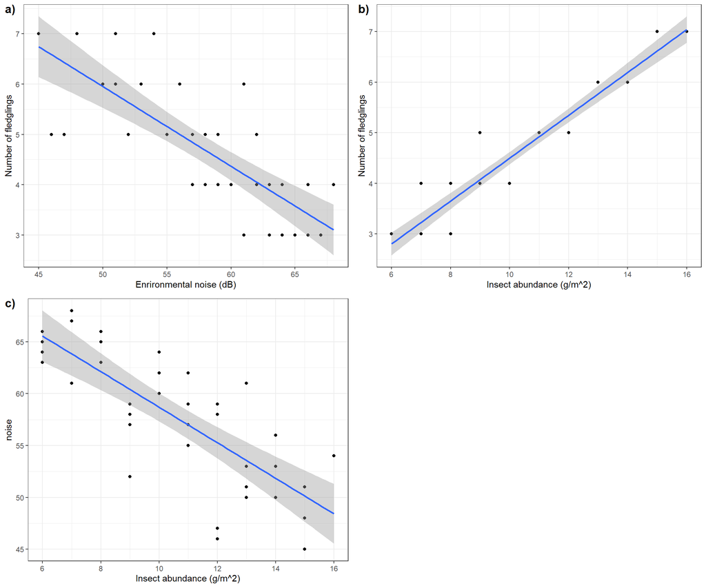

Figure 1: Exploratory plots; a) higher environmental noise (dB) is associated with fewer fledglings; b) higher insect abundance (g/m^2) is associated with a greater number of fledglings; c) higher environemntal nosie (dB) is associated with a lower insect abundace (g(m^2))

```r
ggarrange(
  ggplot(urb_fledg, aes(x=environmental_noise_dB, y=number_of_fledglings))+
    geom_point()+
    geom_smooth(method="lm")+
    xlab("Enrironmental noise (dB)")+
    ylab("Number of fledglings")
  ,

  ggplot(urb_fledg, aes(x=insect_abundance_g_m_2, y=number_of_fledglings))+
    geom_point()+
    geom_smooth(method="lm")+
    xlab("Insect abundance (g/m^2)")+
    ylab("Number of fledglings"),

  ggplot(urb_fledg, aes(x=insect_abundance_g_m_2, y=environmental_noise_dB))+
    geom_point()+
    geom_smooth(method="lm")+
    xlab("Insect abundance (g/m^2)")+
    ylab("noise"),
  common.legend = TRUE, labels=c("a)", "b)", "c)")

)
```

As we can see in the Figure 1 we have a positive correlation between the number of fledglings and the insect abundance, a negative correlation between the environmental noise and the number of fledglings as well as between environmental noise and insect abundance.

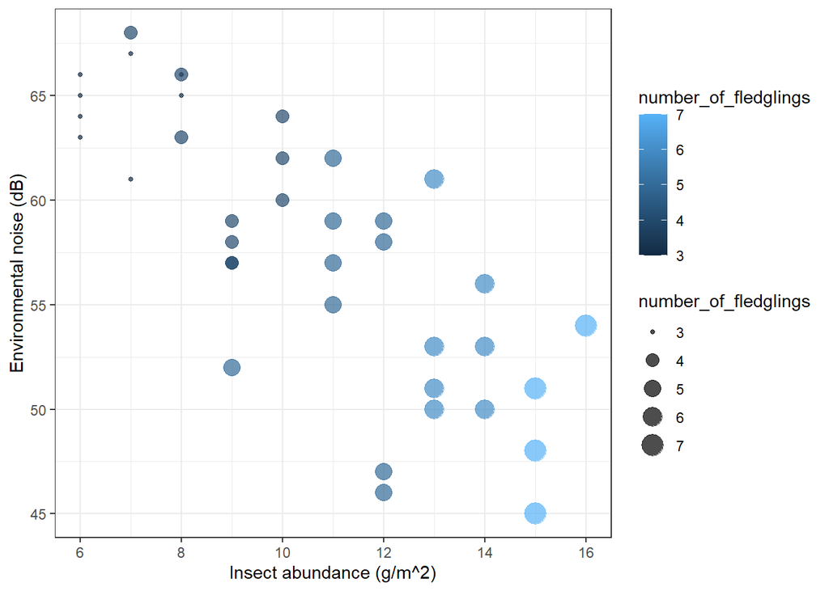

Figure 2: Insect abundance plotted against environmental noise, with point size representing the number of fledglings.

```r
ggplot(urb_fledg, aes(x=insect_abundance_g_m_2, y=environmental_noise_dB))+
  geom_point(aes(size=number_of_fledglings, color=number_of_fledglings), alpha=.7)+
  xlab("Insect abundance (g/m^2)")+
  ylab("Environmental noise (dB)")
```

Once again we plot it all together for completeness in Figure 2.

# 2 Fit the models

## 2.1 Fit candidate models

```r
model.00<-glm(number_of_fledglings~1, urb_fledg, family=poisson)
model.01<-glm(number_of_fledglings~insect_abundance_g_m_2, urb_fledg, family=poisson)
model.02<-glm(number_of_fledglings~insect_abundance_g_m_2+environmental_noise_dB, urb_fledg, family=poisson)
model.03<-glm(number_of_fledglings~insect_abundance_g_m_2*environmental_noise_dB, urb_fledg, family=poisson)

knitr::kable(compare_performance(model.00, model.01, model.02, model.03), digits=3)
model.04<-glm(insect_abundance_g_m_2~environmental_noise_dB, urb_fledg, family=poisson())
```

Table 1: Candidate model comparisons

| Name | Model | AIC | AIC_wt | AICc | AICc_wt | BIC | BIC_wt | R2_Nagelkerke | RMSE | Sigma | Score_log | Score_spherical |
| --- | --- | --- | --- | --- | --- | --- | --- | --- | --- | --- | --- | --- |
| model.00 | glm | 143.887 | 0.004 | 143.998 | 0.005 | 145.524 | 0.012 | 0.000 | 1.275 | 1 | -1.867 | 0.160 |
| model.01 | glm | 133.798 | 0.656 | 134.141 | 0.708 | 137.073 | 0.827 | 0.932 | 0.341 | 1 | -1.708 | 0.161 |
| model.02 | glm | 135.743 | 0.248 | 136.448 | 0.223 | 140.655 | 0.138 | 0.936 | 0.330 | 1 | -1.707 | 0.161 |
| model.03 | glm | 137.729 | 0.092 | 138.941 | 0.064 | 144.279 | 0.023 | 0.937 | 0.328 | 1 | -1.707 | 0.161 |

# 3 Check model diagnostics

```r
#check overdispersion

check_overdispersion(model.02)
```

```
# Overdispersion test

       dispersion ratio = 0.029
  Pearson's Chi-Squared = 1.005
                p-value =     1
```

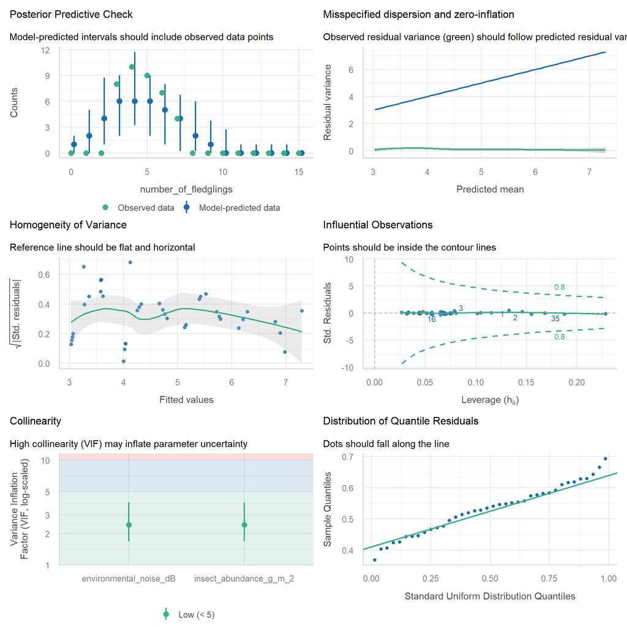

Figure 3: Diagnostic plots

```r
check_model(model.02)
```

In Figure 3 we can see that there appears to be no high collinearity between the variables, the homoscedasticity assumption is also met as well as the Normality (normal residuals distribution) and Linearity(trends in the residuals). Also we can detect no outliers/influencial points in the Cook’s plot.

## 3.1 Interpret the chosen model

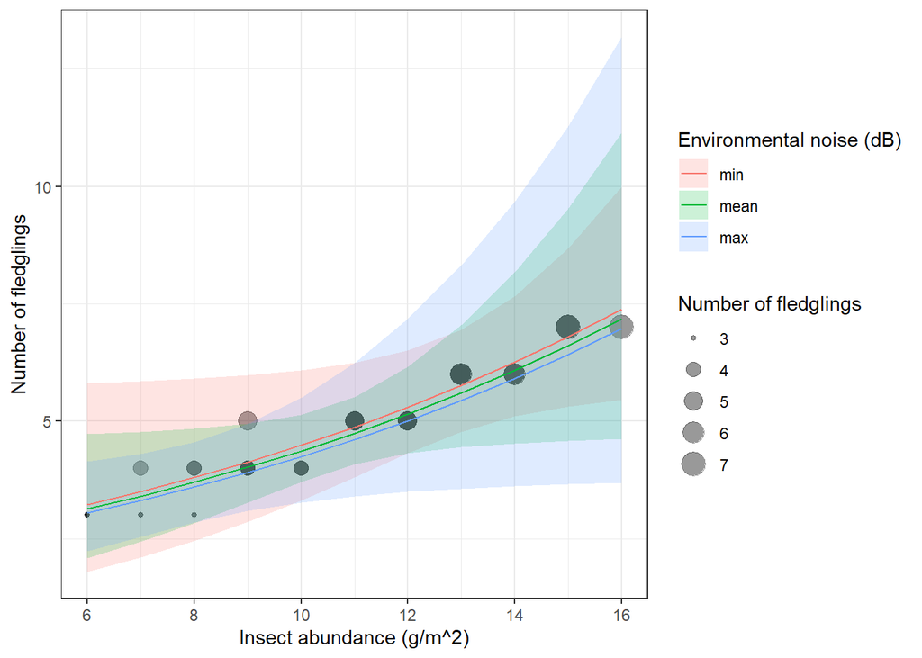

```r
coef_table_03<-round(summary(model.03)$coefficients,3)
coef_table_02<-round(summary(model.02)$coefficients,3)


r.2<-round(attributes(r.squaredLR(model.02))$adj.r.squared,3)

null_chi<-anova(model.00, model.02)


## Interaction plot -----
pred.both<-predict_response(model.02, terms=c("insect_abundance_g_m_2", "environmental_noise_dB"))

pred.both$group<-factor(pred.both$group, labels=c("min", "mean", "max"))

  # Create plot
ggplot(pred.both, aes(x=x, y=predicted)) +
    geom_point(data= urb_fledg, aes(y=number_of_fledglings, x=insect_abundance_g_m_2, size= number_of_fledglings), alpha= .4) +
    geom_ribbon(aes(ymin= conf.low, ymax= conf.high,
                    fill= group), alpha= .2) +
    geom_line(aes(col= group))+
  labs(
    color = "Environmental noise (dB)",
    fill = "Environmental noise (dB)",
    size = "Number of fledglings"
  )+
  xlab("Insect abundance (g/m^2)")+
  ylab("Number of fledglings")
```

```r
knitr::kable(coef_table_02)
```

Table 2: Estimates, associated standard errors and statistical significance of the parameters estimated by a poisson GLM ($R^2$= 0.28 , $\chi^2_{( 2 , 35 )}$= 12.144 , $p$ = 0.002 )

|  | Estimate | Std. Error | z value | Pr(>\|z\|) |
| --- | --- | --- | --- | --- |
| (Intercept) | 0.896 | 1.417 | 0.632 | 0.527 |
| insect_abundance_g_m_2 | 0.083 | 0.041 | 2.043 | 0.041 |
| environmental_noise_dB | -0.004 | 0.018 | -0.236 | 0.814 |

A poisson Generalized Linear Model (*R*<sup>2</sup>= 0.28 , $\chi^2_{( 2 , 35 )}$= 12.144 , *p*= 0.0023064; Table 2) performed significantly better than a null model, compromising an intercept only. We see a signigicance for the insect abundance variable, explaining number of fledglings found in a nest.($\beta_{insect}$= 0.083 , *SE*= 0.041 , *z*= 2.043, *p*= 0.041) But for the environmental noise no significance in predicting the number of fledglings. ($\beta_{noise}$= -0.004 , *SE*= 0.018 , *z*= -0.236, *p*= 0.814)

The model with an interaction term (Table 1) $model.03$) did not generate compelling support for our prior hypothesized interaction between insect abundance and environmental noise ($\beta_{insect: noise}$= 0.001 , *SE*= 0.005 , *z*= 0.117, *p*= 0.907) on the number of fledglings found in a nest.